# 04 - Modeling

##### Train Set (RFE)

```r
svm_lin_clf_rfe <- train_model("svmLinear2", train_set_rfe)
```

```
Support Vector Machines with Linear Kernel

964 samples
 12 predictor
  3 classes: 'Low', 'Moderate', 'High'

No pre-processing
Resampling: Cross-Validated (10 fold, repeated 10 times)
Summary of sample sizes: 868, 868, 868, 868, 867, 868, ...
Resampling results across tuning parameters:

  cost  Accuracy   Kappa
  0.25  0.7398303  0.5255129
  0.50  0.7428383  0.5319220
  1.00  0.7427363  0.5326472

Accuracy was used to select the optimal model using the largest value.
The final value used for the model was cost = 0.5.
```

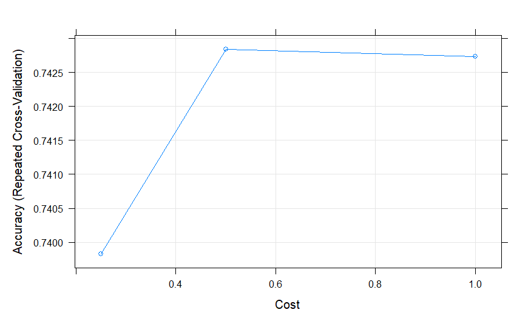

```r
plot(svm_lin_clf_rfe)
```

Perform hyperparameter tuning using `tuneGrid`.

```r
svm_lin_tuneGrid_rfe <- expand.grid(cost = seq(0.2, 1, 0.1))

svm_lin_clf_rfe <- train_model(
  "svmLinear2",
  train_set_rfe,
  tuneGrid = svm_lin_tuneGrid_rfe
)
```

```
Support Vector Machines with Linear Kernel

964 samples
 12 predictor
  3 classes: 'Low', 'Moderate', 'High'

No pre-processing
Resampling: Cross-Validated (10 fold, repeated 10 times)
Summary of sample sizes: 868, 868, 868, 868, 867, 868, ...
Resampling results across tuning parameters:

  cost  Accuracy   Kappa
  0.2   0.7377567  0.5209697
  0.3   0.7398314  0.5258933
  0.4   0.7428404  0.5317684
  0.5   0.7428383  0.5319220
  0.6   0.7419018  0.5305308
  0.7   0.7417988  0.5308206
  0.8   0.7425290  0.5320987
  0.9   0.7424259  0.5321570
  1.0   0.7427363  0.5326472

Accuracy was used to select the optimal model using the largest value.
The final value used for the model was cost = 0.4.
```

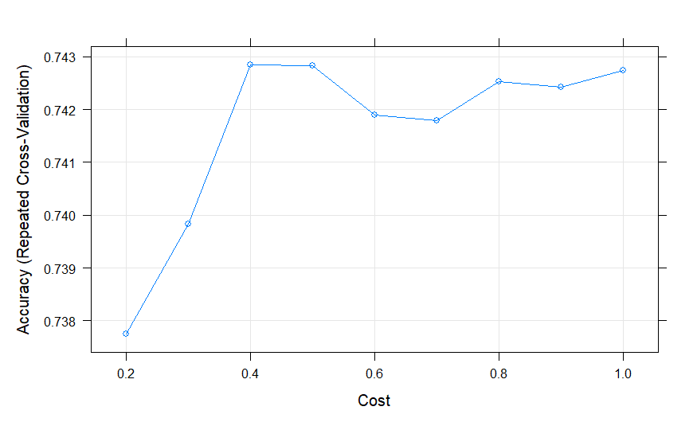

```r
plot(svm_lin_clf_rfe)
```

Tuning done.

```r
svm_lin_metrics_rfe <- evaluate_model(
  svm_lin_clf_rfe,
  "SVM - Linear",
  test_set_rfe,
  "SVM"
)
```

```
Confusion Matrix and Statistics

          Reference
Prediction Low Moderate High
  Low       74       27    3
  Moderate  22       94    9
  High       0        4    8

Overall Statistics

               Accuracy : 0.7303
                 95% CI : (0.6696, 0.7853)
    No Information Rate : 0.5187
    P-Value [Acc > NIR] : 1.491e-11

                  Kappa : 0.514

 Mcnemar's Test P-Value : 0.1427

Statistics by Class:

                     Class: Low Class: Moderate Class: High
Precision                0.7115          0.7520     0.66667
Recall                   0.7708          0.7520     0.40000
F1                       0.7400          0.7520     0.50000
Prevalence               0.3983          0.5187     0.08299
Detection Rate           0.3071          0.3900     0.03320
Detection Prevalence     0.4315          0.5187     0.04979
Balanced Accuracy        0.7820          0.7424     0.69095
```

#### Support Vector Machine (Polynomial)

##### Train Set

```r
svm_poly_clf <- train_model("svmPoly")
```

```
Support Vector Machines with Polynomial Kernel

964 samples
 13 predictor
  3 classes: 'Low', 'Moderate', 'High'

No pre-processing
Resampling: Cross-Validated (10 fold, repeated 10 times)
Summary of sample sizes: 868, 868, 868, 868, 867, 868, ...
Resampling results across tuning parameters:

  degree  scale  C     Accuracy   Kappa
  1       0.001  0.25  0.5186856  0.000000000
  1       0.001  0.50  0.5208677  0.005078785
  1       0.001  1.00  0.6290593  0.258932920
```

[output cut: 27 more lines]

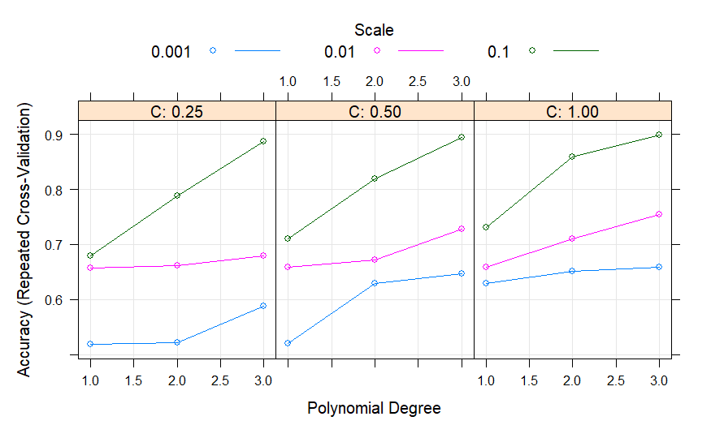

```r
plot(svm_poly_clf)
```

Perform hyperparameter tuning using `tuneGrid`.

```r
svm_poly_tuneGrid <- expand.grid(
  degree = 3:4,
  scale = 0.1,
  C = seq(0.25, 1, 0.05)
)

svm_poly_clf <- train_model("svmPoly", tuneGrid = svm_poly_tuneGrid)
```

```
Support Vector Machines with Polynomial Kernel

964 samples
 13 predictor
  3 classes: 'Low', 'Moderate', 'High'

No pre-processing
Resampling: Cross-Validated (10 fold, repeated 10 times)
Summary of sample sizes: 868, 868, 868, 868, 867, 868, ...
Resampling results across tuning parameters:

  degree  C     Accuracy   Kappa
  3       0.25  0.8867064  0.7961462
  3       0.30  0.8886759  0.7997591
  3       0.35  0.8897090  0.8018548
```

[output cut: 33 more lines]

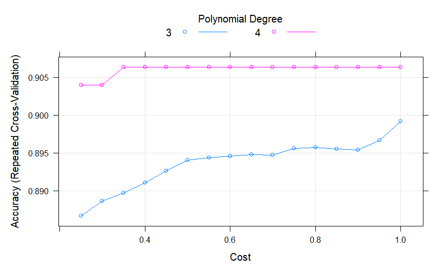

```r
plot(svm_poly_clf)
```

Tuning done.

```r
svm_poly_metrics <- evaluate_model(
  svm_poly_clf,
  "SVM - Polynomial",
  family = "SVM"
)
```

```
Confusion Matrix and Statistics

          Reference
Prediction Low Moderate High
  Low       88       11    0
  Moderate   7      114    6
  High       1        0   14

Overall Statistics

               Accuracy : 0.8963
                 95% CI : (0.8507, 0.9317)
    No Information Rate : 0.5187
    P-Value [Acc > NIR] : < 2e-16

                  Kappa : 0.8141

 Mcnemar's Test P-Value : 0.04836

Statistics by Class:

                     Class: Low Class: Moderate Class: High
Precision                0.8889          0.8976     0.93333
Recall                   0.9167          0.9120     0.70000
F1                       0.9026          0.9048     0.80000
Prevalence               0.3983          0.5187     0.08299
Detection Rate           0.3651          0.4730     0.05809
Detection Prevalence     0.4108          0.5270     0.06224
Balanced Accuracy        0.9204          0.9000     0.84774
```

##### Train Set (RFE)

```r
svm_poly_clf_rfe <- train_model("svmPoly", train_set_rfe)
```

```
Support Vector Machines with Polynomial Kernel

964 samples
 12 predictor
  3 classes: 'Low', 'Moderate', 'High'

No pre-processing
Resampling: Cross-Validated (10 fold, repeated 10 times)
Summary of sample sizes: 868, 868, 868, 868, 867, 868, ...
Resampling results across tuning parameters:

  degree  scale  C     Accuracy   Kappa
  1       0.001  0.25  0.5186856  0.000000000
  1       0.001  0.50  0.5202416  0.003610428
  1       0.001  1.00  0.6264680  0.252564883
```

[output cut: 27 more lines]

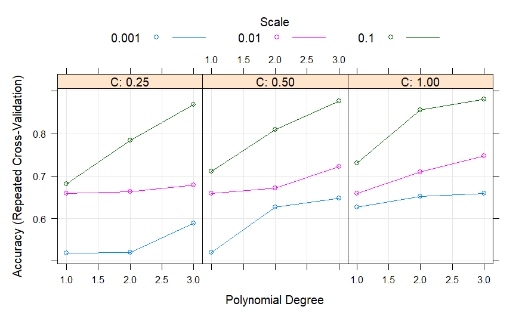

```r
plot(svm_poly_clf_rfe)
```

Perform hyperparameter tuning using `tuneGrid`.

```r
svm_poly_tuneGrid_rfe <- expand.grid(
  degree = 3:4,
  scale = 0.1,
  C = seq(0.25, 1, 0.05)
)

svm_poly_clf_rfe <- train_model(
  "svmPoly",
  train_set_rfe,
  tuneGrid = svm_poly_tuneGrid_rfe
)
```

```
Support Vector Machines with Polynomial Kernel

964 samples
 12 predictor
  3 classes: 'Low', 'Moderate', 'High'

No pre-processing
Resampling: Cross-Validated (10 fold, repeated 10 times)
Summary of sample sizes: 868, 868, 868, 868, 867, 868, ...
Resampling results across tuning parameters:

  degree  C     Accuracy   Kappa
  3       0.25  0.8679177  0.7625549
  3       0.30  0.8708204  0.7676933
  3       0.35  0.8717547  0.7696378
```

[output cut: 33 more lines]

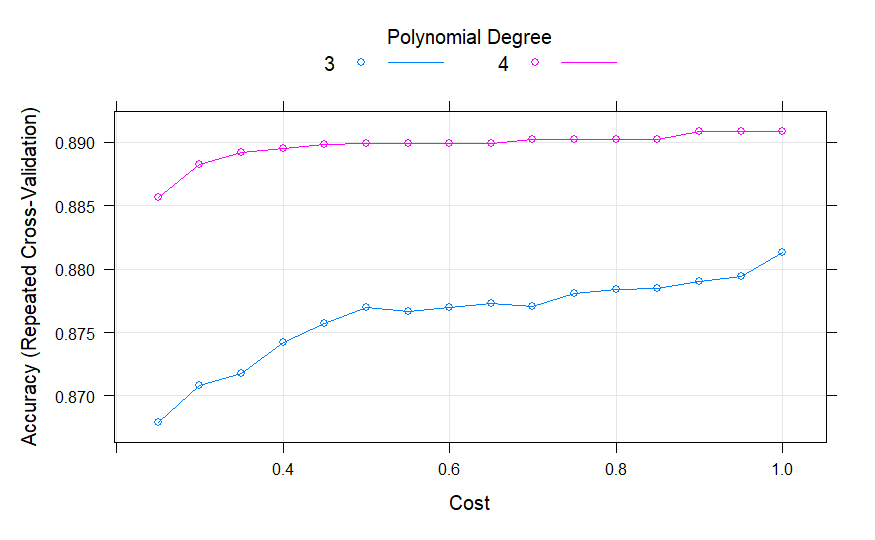

```r
plot(svm_poly_clf_rfe)
```

Tuning done.

```r
svm_poly_metrics_rfe <- evaluate_model(
  svm_poly_clf_rfe,
  "SVM - Polynomial",
  test_set_rfe,
  "SVM"
)
```

```
Confusion Matrix and Statistics

          Reference
Prediction Low Moderate High
  Low       87       12    0
  Moderate   8      113    6
  High       1        0   14

Overall Statistics

               Accuracy : 0.888
                 95% CI : (0.8412, 0.9249)
    No Information Rate : 0.5187
    P-Value [Acc > NIR] : < 2e-16

                  Kappa : 0.7992

 Mcnemar's Test P-Value : 0.05033

Statistics by Class:

                     Class: Low Class: Moderate Class: High
Precision                0.8788          0.8898     0.93333
Recall                   0.9062          0.9040     0.70000
F1                       0.8923          0.8968     0.80000
Prevalence               0.3983          0.5187     0.08299
Detection Rate           0.3610          0.4689     0.05809
Detection Prevalence     0.4108          0.5270     0.06224
Balanced Accuracy        0.9117          0.8917     0.84774
```

#### Support Vector Machine (Radial Basis Function)

##### Train Set

```r
svm_rbf_clf <- train_model("svmRadial")
```

```
Support Vector Machines with Radial Basis Function Kernel

964 samples
 13 predictor
  3 classes: 'Low', 'Moderate', 'High'

No pre-processing
Resampling: Cross-Validated (10 fold, repeated 10 times)
Summary of sample sizes: 868, 868, 868, 868, 867, 868, ...
Resampling results across tuning parameters:

  C     Accuracy   Kappa
  0.25  0.7202266  0.4635128
  0.50  0.7583902  0.5478819
  1.00  0.7695962  0.5735715

Tuning parameter 'sigma' was held constant at a value of 0.02940126
Accuracy was used to select the optimal model using the largest value.
The final values used for the model were sigma = 0.02940126 and C = 1.
```

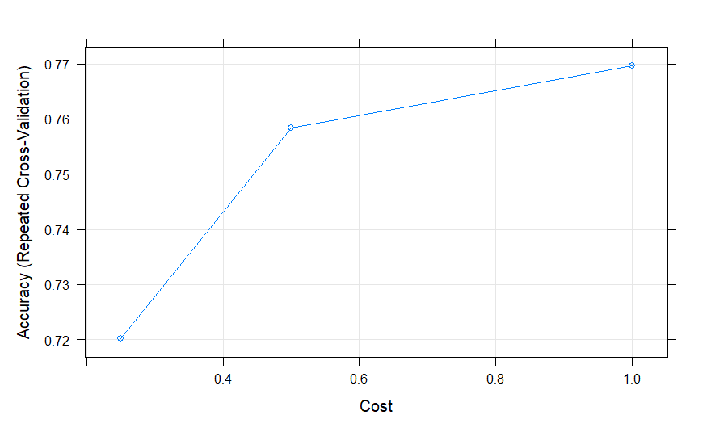

```r
plot(svm_rbf_clf)
```

Perform hyperparameter tuning using `tuneLength`.

```r
svm_rbf_clf <- train_model("svmRadial", tuneLength = 15)
```

```
Support Vector Machines with Radial Basis Function Kernel

964 samples
 13 predictor
  3 classes: 'Low', 'Moderate', 'High'

No pre-processing
Resampling: Cross-Validated (10 fold, repeated 10 times)
Summary of sample sizes: 868, 868, 868, 868, 867, 868, ...
Resampling results across tuning parameters:

  C        Accuracy   Kappa
     0.25  0.7202266  0.4635128
     0.50  0.7583902  0.5478819
     1.00  0.7695962  0.5735715
     2.00  0.7913681  0.6191532
     4.00  0.8342311  0.7004529
     8.00  0.8756153  0.7762735
    16.00  0.8869094  0.7969803
    32.00  0.8943847  0.8109481
    64.00  0.9016527  0.8244757
   128.00  0.9038316  0.8283475
   256.00  0.9038316  0.8283475
   512.00  0.9038316  0.8283475
  1024.00  0.9038316  0.8283475
  2048.00  0.9038316  0.8283475
  4096.00  0.9038316  0.8283475

Tuning parameter 'sigma' was held constant at a value of 0.02940126
Accuracy was used to select the optimal model using the largest value.
The final values used for the model were sigma = 0.02940126 and C = 128.
```

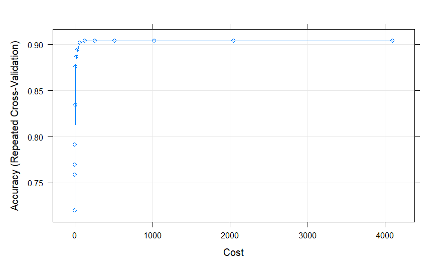

```r
plot(svm_rbf_clf)
```

Tuning done.

```r
svm_rbf_metrics <- evaluate_model(svm_rbf_clf, "SVM - RBF", family = "SVM")
```

```
Confusion Matrix and Statistics

          Reference
Prediction Low Moderate High
  Low       88       11    0
  Moderate   7      114    6
  High       1        0   14

Overall Statistics

               Accuracy : 0.8963
                 95% CI : (0.8507, 0.9317)
    No Information Rate : 0.5187
    P-Value [Acc > NIR] : < 2e-16

                  Kappa : 0.8141

 Mcnemar's Test P-Value : 0.04836

Statistics by Class:

                     Class: Low Class: Moderate Class: High
Precision                0.8889          0.8976     0.93333
Recall                   0.9167          0.9120     0.70000
F1                       0.9026          0.9048     0.80000
Prevalence               0.3983          0.5187     0.08299
Detection Rate           0.3651          0.4730     0.05809
Detection Prevalence     0.4108          0.5270     0.06224
Balanced Accuracy        0.9204          0.9000     0.84774
```

##### Train Set (RFE)

```r
svm_rbf_clf_rfe <- train_model("svmRadial", train_set_rfe)
```

```
Support Vector Machines with Radial Basis Function Kernel

964 samples
 12 predictor
  3 classes: 'Low', 'Moderate', 'High'

No pre-processing
Resampling: Cross-Validated (10 fold, repeated 10 times)
Summary of sample sizes: 868, 868, 868, 868, 867, 868, ...
Resampling results across tuning parameters:

  C     Accuracy   Kappa
  0.25  0.7303887  0.4858431
  0.50  0.7590238  0.5485984
  1.00  0.7734278  0.5812528

Tuning parameter 'sigma' was held constant at a value of 0.03153892
Accuracy was used to select the optimal model using the largest value.
The final values used for the model were sigma = 0.03153892 and C = 1.
```

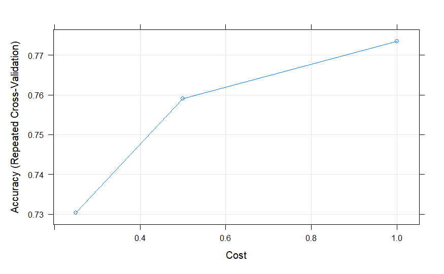

```r
plot(svm_rbf_clf_rfe)
```

Perform hyperparameter tuning using `tuneLength`.

```r
svm_rbf_clf_rfe <- train_model("svmRadial", train_set_rfe, tuneLength = 15)
```

```
Support Vector Machines with Radial Basis Function Kernel

964 samples
 12 predictor
  3 classes: 'Low', 'Moderate', 'High'

No pre-processing
Resampling: Cross-Validated (10 fold, repeated 10 times)
Summary of sample sizes: 868, 868, 868, 868, 867, 868, ...
Resampling results across tuning parameters:

  C        Accuracy   Kappa
     0.25  0.7303887  0.4858431
     0.50  0.7590238  0.5485984
     1.00  0.7734278  0.5812528
     2.00  0.7917902  0.6206137
     4.00  0.8250838  0.6837127
     8.00  0.8612844  0.7507504
    16.00  0.8698851  0.7667172
    32.00  0.8776729  0.7809172
    64.00  0.8892988  0.8023356
   128.00  0.8915851  0.8064555
   256.00  0.8925193  0.8081544
   512.00  0.8925193  0.8081544
  1024.00  0.8925193  0.8081544
  2048.00  0.8925193  0.8081544
  4096.00  0.8925193  0.8081544

Tuning parameter 'sigma' was held constant at a value of 0.03153892
Accuracy was used to select the optimal model using the largest value.
The final values used for the model were sigma = 0.03153892 and C = 256.
```

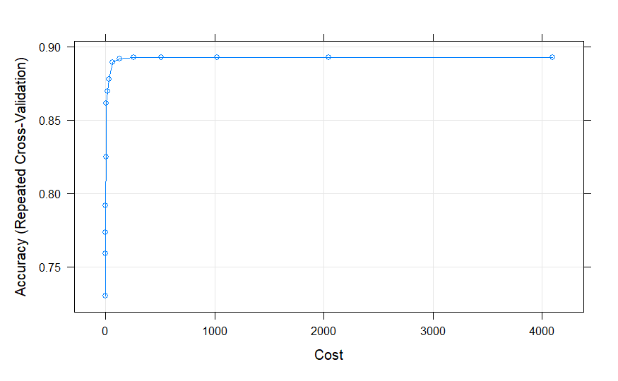

```r
plot(svm_rbf_clf_rfe)
```

Tuning done.

```r
svm_rbf_metrics_rfe <- evaluate_model(
  svm_rbf_clf_rfe,
  "SVM - RBF",
  test_set_rfe,
  "SVM"
)
```

```
Confusion Matrix and Statistics

          Reference
Prediction Low Moderate High
  Low       88       12    0
  Moderate   7      113    6
  High       1        0   14

Overall Statistics

               Accuracy : 0.8921
                 95% CI : (0.8459, 0.9283)
    No Information Rate : 0.5187
    P-Value [Acc > NIR] : < 2e-16

                  Kappa : 0.8068

 Mcnemar's Test P-Value : 0.03992

Statistics by Class:

                     Class: Low Class: Moderate Class: High
Precision                0.8800          0.8968     0.93333
Recall                   0.9167          0.9040     0.70000
F1                       0.8980          0.9004     0.80000
Prevalence               0.3983          0.5187     0.08299
Detection Rate           0.3651          0.4689     0.05809
Detection Prevalence     0.4149          0.5228     0.06224
Balanced Accuracy        0.9170          0.8960     0.84774
```

### Evaluation

Set theme.

```r
theme_set(theme_bw())
```

Define color palette.

```r
custom_palette <- scale_fill_brewer(palette = "Pastel2")
```

Define a function to aggregate accuracy from model of same family.

```r
aggregate_accuracy <- function(df) {
  df_accuracy <- df %>%
    group_by(Family) %>%
    slice(which.max(Accuracy)) %>%
    arrange(desc(Accuracy)) %>%
    select(-1)

  print(df_accuracy)

  plot_accuracy <- df_accuracy %>%
    ggplot(aes(x = reorder(Family, -Accuracy), y = Accuracy, fill = Family)) +
    geom_bar(stat = "identity") +
    geom_text(aes(label = Accuracy), vjust=-0.5) +
    ggtitle("Accuracy by Model") +
    xlab("Model") +
    ylim(0, 1) +
    labs(fill = "Model") +
    theme(axis.text.x = element_text(angle = 90, vjust = 0.5, hjust=1)) +
    custom_palette

  print(plot_accuracy)
}
```

Define a function to aggregate recall score from model of same family.

```r
aggregate_recall_low <- function(df) {
  df_recall_low <- df %>%
    group_by(Family) %>%
    slice(which.max(Recall.Low)) %>%
    arrange(desc(Recall.Low)) %>%
    select(-1)

  print(df_recall_low)

  plot_recall_low <- df_recall_low %>%
    ggplot(aes(x = reorder(Family, -Recall.Low), y = Recall.Low, fill = Family)) +
    geom_bar(stat = "identity") +
    geom_text(aes(label = Recall.Low), vjust=-0.5) +
    ggtitle("Recall (Low Adaptability) by Model") +
    xlab("Model") +
    ylab("Recall") +
    ylim(0, 1) +
    labs(fill = "Model") +
    theme(axis.text.x = element_text(angle = 90, vjust = 0.5, hjust=1)) +
    custom_palette

  print(plot_recall_low)
}
```

#### Train Set

```r
df_eval <- rbind(
  lr_metrics,
  knn_metrics,
  nb_metrics,
  dt_metrics,
  rf_metrics,
  xgb_tree_metrics,
  xgb_lin_metrics,
  svm_lin_metrics,
  svm_poly_metrics,
  svm_rbf_metrics
)

df_eval
```

| Model | Family | Accuracy | Precision.Low | Recall.Low | F1.Low | Precision.Moderate | Recall.Moderate | F1.Moderate | Precision.High | Recall.High | F1.High |
| --- | --- | --- | --- | --- | --- | --- | --- | --- | --- | --- | --- |
| LR | LR | 0.668 | 0.670 | 0.656 | 0.663 | 0.687 | 0.720 | 0.703 | 0.500 | 0.4 | 0.444 |
| KNN | KNN | 0.921 | 0.937 | 0.927 | 0.932 | 0.908 | 0.952 | 0.930 | 0.933 | 0.7 | 0.800 |
| NB | NB | 0.651 | 0.684 | 0.542 | 0.605 | 0.640 | 0.840 | 0.727 | 0.000 | 0.0 | NaN |
| DT | DT | 0.726 | 0.768 | 0.656 | 0.708 | 0.718 | 0.816 | 0.764 | 0.588 | 0.5 | 0.541 |
| RF | RF | 0.921 | 0.937 | 0.927 | 0.932 | 0.908 | 0.952 | 0.930 | 0.933 | 0.7 | 0.800 |
| XGB - Tree | XGB | 0.917 | 0.936 | 0.917 | 0.926 | 0.902 | 0.952 | 0.926 | 0.933 | 0.7 | 0.800 |
| XGB - Linear | XGB | 0.913 | 0.936 | 0.917 | 0.926 | 0.901 | 0.944 | 0.922 | 0.875 | 0.7 | 0.778 |
| SVM - Linear | SVM | 0.730 | 0.714 | 0.781 | 0.746 | 0.756 | 0.744 | 0.750 | 0.615 | 0.4 | 0.485 |
| SVM - Polynomial | SVM | 0.896 | 0.889 | 0.917 | 0.903 | 0.898 | 0.912 | 0.905 | 0.933 | 0.7 | 0.800 |
| SVM - RBF | SVM | 0.896 | 0.889 | 0.917 | 0.903 | 0.898 | 0.912 | 0.905 | 0.933 | 0.7 | 0.800 |

##### By Accuracy

| Family | Accuracy | Precision.Low | Recall.Low | F1.Low | Precision.Moderate | Recall.Moderate | F1.Moderate | Precision.High | Recall.High | F1.High |
| --- | --- | --- | --- | --- | --- | --- | --- | --- | --- | --- |
| KNN | 0.921 | 0.937 | 0.927 | 0.932 | 0.908 | 0.952 | 0.930 | 0.933 | 0.7 | 0.800 |
| RF | 0.921 | 0.937 | 0.927 | 0.932 | 0.908 | 0.952 | 0.930 | 0.933 | 0.7 | 0.800 |
| XGB | 0.917 | 0.936 | 0.917 | 0.926 | 0.902 | 0.952 | 0.926 | 0.933 | 0.7 | 0.800 |
| SVM | 0.896 | 0.889 | 0.917 | 0.903 | 0.898 | 0.912 | 0.905 | 0.933 | 0.7 | 0.800 |
| DT | 0.726 | 0.768 | 0.656 | 0.708 | 0.718 | 0.816 | 0.764 | 0.588 | 0.5 | 0.541 |
| LR | 0.668 | 0.670 | 0.656 | 0.663 | 0.687 | 0.720 | 0.703 | 0.500 | 0.4 | 0.444 |
| NB | 0.651 | 0.684 | 0.542 | 0.605 | 0.640 | 0.840 | 0.727 | 0.000 | 0.0 | NaN |

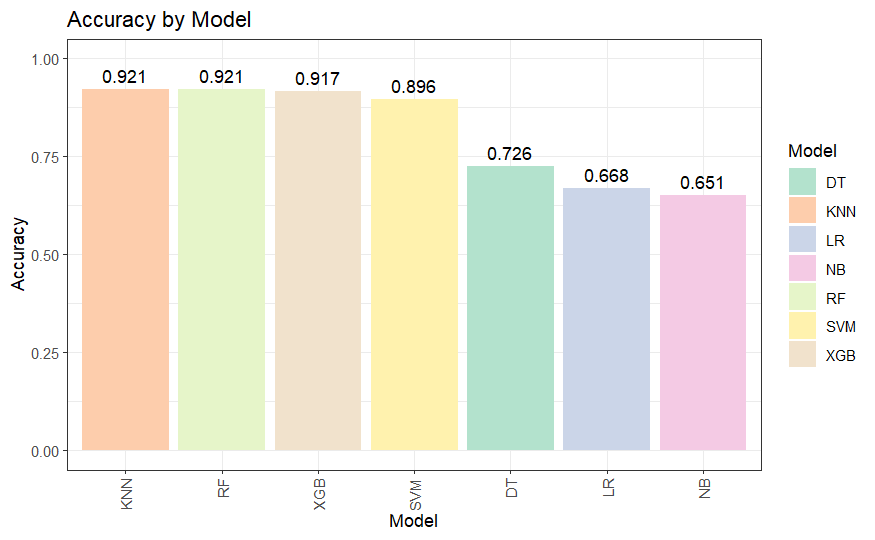

```r
aggregate_accuracy(df_eval)
```

##### By Recall (Low Adaptability)

| Family | Accuracy | Precision.Low | Recall.Low | F1.Low | Precision.Moderate | Recall.Moderate | F1.Moderate | Precision.High | Recall.High | F1.High |
| --- | --- | --- | --- | --- | --- | --- | --- | --- | --- | --- |
| KNN | 0.921 | 0.937 | 0.927 | 0.932 | 0.908 | 0.952 | 0.930 | 0.933 | 0.7 | 0.800 |
| RF | 0.921 | 0.937 | 0.927 | 0.932 | 0.908 | 0.952 | 0.930 | 0.933 | 0.7 | 0.800 |
| SVM | 0.896 | 0.889 | 0.917 | 0.903 | 0.898 | 0.912 | 0.905 | 0.933 | 0.7 | 0.800 |
| XGB | 0.917 | 0.936 | 0.917 | 0.926 | 0.902 | 0.952 | 0.926 | 0.933 | 0.7 | 0.800 |
| DT | 0.726 | 0.768 | 0.656 | 0.708 | 0.718 | 0.816 | 0.764 | 0.588 | 0.5 | 0.541 |
| LR | 0.668 | 0.670 | 0.656 | 0.663 | 0.687 | 0.720 | 0.703 | 0.500 | 0.4 | 0.444 |
| NB | 0.651 | 0.684 | 0.542 | 0.605 | 0.640 | 0.840 | 0.727 | 0.000 | 0.0 | NaN |

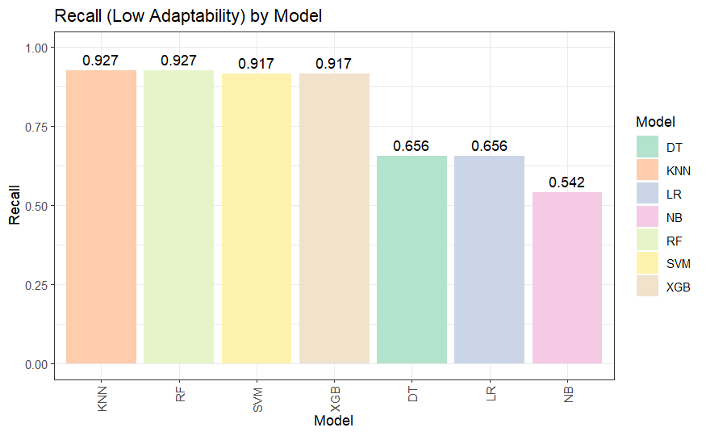

```r
aggregate_recall_low(df_eval)
```

#### Train Set (RFE)

```r
df_eval_rfe <- rbind(
  lr_metrics_rfe,
  knn_metrics_rfe,
  nb_metrics_rfe,
  dt_metrics_rfe,
  rf_metrics_rfe,
  xgb_tree_metrics_rfe,
  xgb_lin_metrics_rfe,
  svm_lin_metrics_rfe,
  svm_poly_metrics_rfe,
  svm_rbf_metrics_rfe
)

df_eval_rfe
```

| Model | Family | Accuracy | Precision.Low | Recall.Low | F1.Low | Precision.Moderate | Recall.Moderate | F1.Moderate | Precision.High | Recall.High | F1.High |
| --- | --- | --- | --- | --- | --- | --- | --- | --- | --- | --- | --- |
| LR | LR | 0.676 | 0.677 | 0.677 | 0.677 | 0.698 | 0.720 | 0.709 | 0.500 | 0.4 | 0.444 |
| KNN | KNN | 0.896 | 0.889 | 0.917 | 0.903 | 0.898 | 0.912 | 0.905 | 0.933 | 0.7 | 0.800 |
| NB | NB | 0.643 | 0.667 | 0.542 | 0.598 | 0.636 | 0.824 | 0.718 | 0.000 | 0.0 | NaN |
| DT | DT | 0.726 | 0.768 | 0.656 | 0.708 | 0.718 | 0.816 | 0.764 | 0.588 | 0.5 | 0.541 |
| RF | RF | 0.905 | 0.935 | 0.896 | 0.915 | 0.887 | 0.944 | 0.915 | 0.875 | 0.7 | 0.778 |
| XGB - Tree | XGB | 0.884 | 0.894 | 0.875 | 0.884 | 0.871 | 0.920 | 0.895 | 0.933 | 0.7 | 0.800 |
| XGB - Linear | XGB | 0.892 | 0.896 | 0.896 | 0.896 | 0.885 | 0.920 | 0.902 | 0.933 | 0.7 | 0.800 |
| SVM - Linear | SVM | 0.730 | 0.712 | 0.771 | 0.740 | 0.752 | 0.752 | 0.752 | 0.667 | 0.4 | 0.500 |
| SVM - Polynomial | SVM | 0.888 | 0.879 | 0.906 | 0.892 | 0.890 | 0.904 | 0.897 | 0.933 | 0.7 | 0.800 |
| SVM - RBF | SVM | 0.892 | 0.880 | 0.917 | 0.898 | 0.897 | 0.904 | 0.900 | 0.933 | 0.7 | 0.800 |

##### By Accuracy

| Family | Accuracy | Precision.Low | Recall.Low | F1.Low | Precision.Moderate | Recall.Moderate | F1.Moderate | Precision.High | Recall.High | F1.High |
| --- | --- | --- | --- | --- | --- | --- | --- | --- | --- | --- |
| RF | 0.905 | 0.935 | 0.896 | 0.915 | 0.887 | 0.944 | 0.915 | 0.875 | 0.7 | 0.778 |
| KNN | 0.896 | 0.889 | 0.917 | 0.903 | 0.898 | 0.912 | 0.905 | 0.933 | 0.7 | 0.800 |
| SVM | 0.892 | 0.880 | 0.917 | 0.898 | 0.897 | 0.904 | 0.900 | 0.933 | 0.7 | 0.800 |
| XGB | 0.892 | 0.896 | 0.896 | 0.896 | 0.885 | 0.920 | 0.902 | 0.933 | 0.7 | 0.800 |
| DT | 0.726 | 0.768 | 0.656 | 0.708 | 0.718 | 0.816 | 0.764 | 0.588 | 0.5 | 0.541 |
| LR | 0.676 | 0.677 | 0.677 | 0.677 | 0.698 | 0.720 | 0.709 | 0.500 | 0.4 | 0.444 |
| NB | 0.643 | 0.667 | 0.542 | 0.598 | 0.636 | 0.824 | 0.718 | 0.000 | 0.0 | NaN |

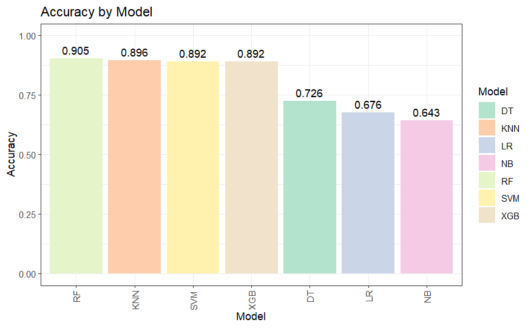

```r
aggregate_accuracy(df_eval_rfe)
```

##### By Recall (Low Adaptability)

| Family | Accuracy | Precision.Low | Recall.Low | F1.Low | Precision.Moderate | Recall.Moderate | F1.Moderate | Precision.High | Recall.High | F1.High |
| --- | --- | --- | --- | --- | --- | --- | --- | --- | --- | --- |
| KNN | 0.896 | 0.889 | 0.917 | 0.903 | 0.898 | 0.912 | 0.905 | 0.933 | 0.7 | 0.800 |
| SVM | 0.892 | 0.880 | 0.917 | 0.898 | 0.897 | 0.904 | 0.900 | 0.933 | 0.7 | 0.800 |
| RF | 0.905 | 0.935 | 0.896 | 0.915 | 0.887 | 0.944 | 0.915 | 0.875 | 0.7 | 0.778 |
| XGB | 0.892 | 0.896 | 0.896 | 0.896 | 0.885 | 0.920 | 0.902 | 0.933 | 0.7 | 0.800 |
| LR | 0.676 | 0.677 | 0.677 | 0.677 | 0.698 | 0.720 | 0.709 | 0.500 | 0.4 | 0.444 |
| DT | 0.726 | 0.768 | 0.656 | 0.708 | 0.718 | 0.816 | 0.764 | 0.588 | 0.5 | 0.541 |
| NB | 0.643 | 0.667 | 0.542 | 0.598 | 0.636 | 0.824 | 0.718 | 0.000 | 0.0 | NaN |

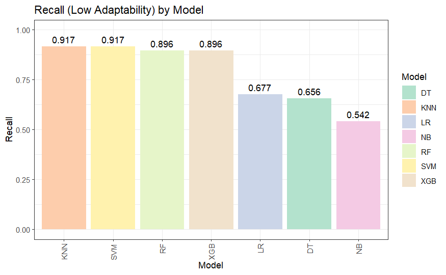

```r
aggregate_recall_low(df_eval_rfe)
```

### Model Selection

Both K-Nearest Neighbors and Random Forest perform the best with all features selected.

We will choose K-Nearest Neighbors due to its simplicity.